# R functions for data diagnostics

shelby bachman

Functions described below:

- `check_normality()` / [source code](https://raw.githubusercontent.com/shelbybachman/useful-R-tools/master/check_normality.R)
- `check_outliers()` / [source code](https://raw.githubusercontent.com/shelbybachman/useful-R-tools/master/check_outliers.R)
- `check_collinearity()` / [source code](https://raw.githubusercontent.com/shelbybachman/useful-R-tools/master/check-collinearity.R)

These functions **perform checks of parametric assumptions** and **detect outliers**. These functions have a few dependencies which need to be installed but not loaded: `ggplot2` and `ggpubr`. To illustrate how to use these functions, I will use data from the `swiss` dataset that comes built-in with R:

```
##              Fertility Agriculture Examination Education Catholic
## Courtelary        80.2        17.0          15        12     9.96
## Delemont          83.1        45.1           6         9    84.84
## Franches-Mnt      92.5        39.7           5         5    93.40
## Moutier           85.8        36.5          12         7    33.77
## Neuveville        76.9        43.5          17        15     5.16
## Porrentruy        76.1        35.3           9         7    90.57
##              Infant.Mortality
## Courtelary               22.2
## Delemont                 22.2
## Franches-Mnt             20.2
## Moutier                  20.3
## Neuveville               20.6
## Porrentruy               26.6
```

# check_normality()

This function **checks data contained in a vector for normality**. The function takes a vector as input and returns values of skewness (`output[[1]]`), kurtosis (`output[[2]]`), a message about whether severe non-normality is indicated (`output[[3]]`), and displays these values along with two plots (`output[[4]]`): a frequency distribution with the mean indicated with a dashed line, and a normal probability plot. It takes two mandatory arguments, a vector of values `data` and a name for the data `name`, as well as an optional argument `colour` specifying the color for the plots (it uses mint green by default).

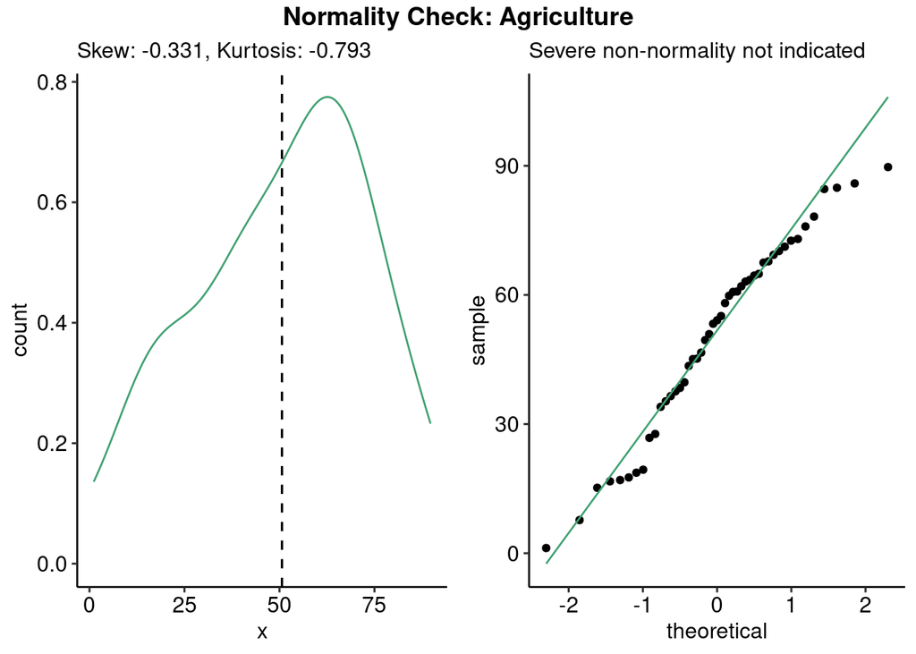

```r
check_normality(data = swiss$Agriculture, name = 'Agriculture')[[4]]
```

# check_outliers()

This function **checks data contained in a vector for outliers**. The function detects outliers using the MAD-median rule, returns the row indices of those outliers (`output[[1]]`), and also displays a boxplot showing outliers identified according to the (non-robust) boxplot rule (`output[[2]]`). It takes two mandatory arguments, a vector of values `data` and a name for the data `name`, as well as an optional argument `colour` specifying the color for the plots (it uses mint green by default).

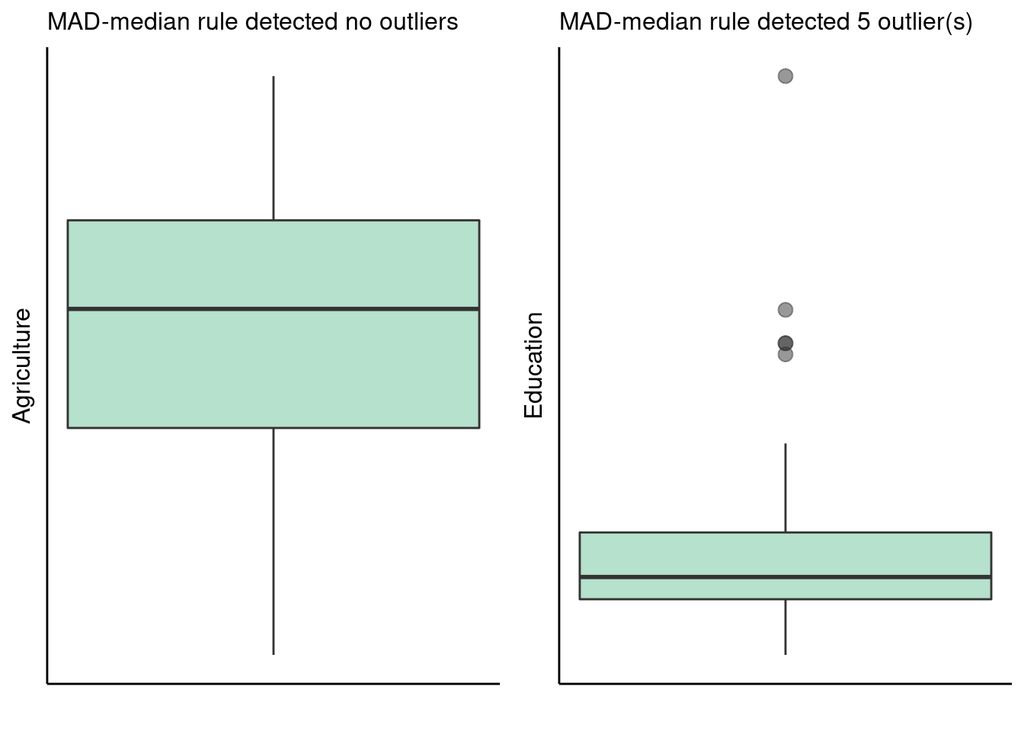

```r
ggpubr::ggarrange(check_outliers(data = swiss$Agriculture, name = 'Agriculture')[[2]],
                   check_outliers(data = swiss$Education, name = 'Education')[[2]])
```

# check_collinearity()

This function **checks two variables in a dataframe for extreme collinearity**. Given a dataframe and two variables of interest within that dataframe, it returns values of $R^2$ (`output[[1]]`), tolerance (`output[[2]]`), and a variance inflation factor (VIF) (`output[[3]]`), as well as these values superimposed on a scatterplot showing a linear regression line through the data (`output[[4]]`). It takes three arguments, a dataframe `data` as well as the names of two variables in the dataframe as the subsequent arguments.

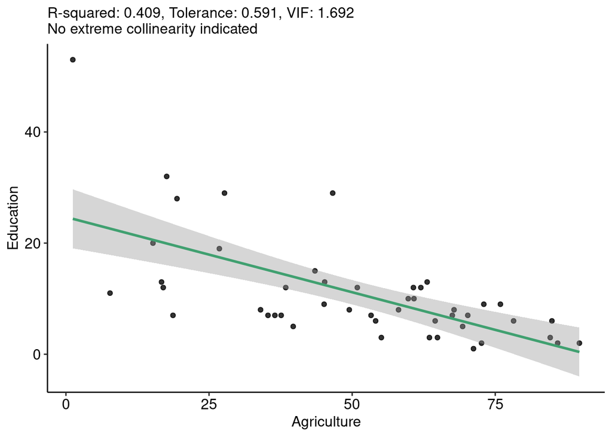

```r
check_collinearity(swiss, 'Agriculture', 'Education')[[4]]
```